# DSLAB - Covid19 Lombardia

GIORGIO NARDI ERIC SPINELLI

## Importazione dei dati

```r
library(dplyr)
library(tidyr)
library(ggplot2)
```

In primo luogo si procede con la pulizia del dataset andando a rimuovere le variabili superflue. In seguito, viene utilizzata la variabile GE per creare una nuova variabile che corrisponde alla data del decesso. L’anno 2020 viene aggiunto solamente per ottenere la trasformazione in formato data.

```r
dati=dati[,-c(10:21)]
dati %>% mutate(DATA = as.Date(paste0("0", GE,"2020"),format = "%m%d%Y")) -> dati
```

## Trattazione comuni senza valori mancanti

Viene filtrato il dataset di partenza selezionando la Lombardia come regione d’interesse, escudendo i casi a cui è assegnato 9999. Viene considerato esclusivamente il periodo tra 22/02 (GE=222) e 4/04 (GE=404) dato che il primo caso di COVID-19 venne registrato proprio il 22 Febbraio. Ottenuto il nuovo dataset venngono raggruppati i decessi per giorno ottenendo il set di dati lomb. Successivamente, viene creata una nuova variabile che corrisponde alla media dei decessi negli anni precedenti. Per il 29 Febbraio viene imputato manualmente il valore, considerando che ogni anno del quinquennio precedente ha avuto un numero di morti pari al 2016. Da ultimo vengono calcolati i totali di decessi per ogni anno nel quinquennio 2015-2019 condizionatamente al periodo considerato.I valori vengono inseriti in un vettore.

```r
dati%>% filter(NOME_REGIONE == "Lombardia",
               TOTALE_20 < 9999,
               GE>=222,
               GE<=404) -> wdt

wdt %>% group_by(DATA) %>%
  summarise(TOTALE_15 = sum(TOTALE_15),TOTALE_16=sum(TOTALE_16),
            TOTALE_17=sum(TOTALE_17),TOTALE_18=sum(TOTALE_18),
            TOTALE_19=sum(TOTALE_19),TOTALE_20=sum(TOTALE_20)) -> lomb


lomb$mediaanniprec=(lomb$TOTALE_15+lomb$TOTALE_16+lomb$TOTALE_17+
                      lomb$TOTALE_18+lomb$TOTALE_19)/5


lomb[8,'mediaanniprec']<-201
lomb[8,'TOTALE_15']<-201
lomb[8,'TOTALE_17']<-201
lomb[8,'TOTALE_18']<-201
lomb[8,'TOTALE_19']<-201

tot_morti_15=sum(lomb$TOTALE_15)
tot_morti_16=sum(lomb$TOTALE_16)
tot_morti_17=sum(lomb$TOTALE_17)
tot_morti_18=sum(lomb$TOTALE_18)
tot_morti_19=sum(lomb$TOTALE_19)
vett=c(tot_morti_15,tot_morti_16,tot_morti_17,tot_morti_18,tot_morti_19)
```

Si ottiene un primo intervallo dato dalla differenza tra i decessi totali del 2020 nel periodo dal 22 Febbraio al 4 aprile e la media di decessi degli anni precedenti nel medesimo periodo. Per tenere conto della variabilità si è deciso di considerare un intervallo per la media aggiungendo e togliendo la deviazione standard, in modo tale da tenere conto della dispersione dei dati intorno alla media. Non è stata applicata una stima intervallare utilizzando le distribuzioni di probabilità data lo scarso numero di osservazioni (n=5) e la non conoscenza della distribuzione della popolazione di provenienza dei dati.

```r
rangeinf=sum(lomb$TOTALE_20)-(mean(vett)+sd(vett))
rangesup=sum(lomb$TOTALE_20)-(mean(vett)-sd(vett))
range=c(rangeinf,rangesup)
range
```

```
## [1] 12524.38 13158.82
```

L’intervallo così ottenuto esprime l’impatto del COVID-19 sui decessi solo nei comuni che nel dataset fornito da ISTAT presentano dati affidabili del 2020. Si procederà in seguito a perfezionare tale intervallo cercando di effettuare una stima per quei comuni che presentano valori mancanti. Viene realizzato inoltre un grafico che rappresenta una stima intervallare giornaliera riguardo l’impatto del COVID sui decessi nel periodo considerato.

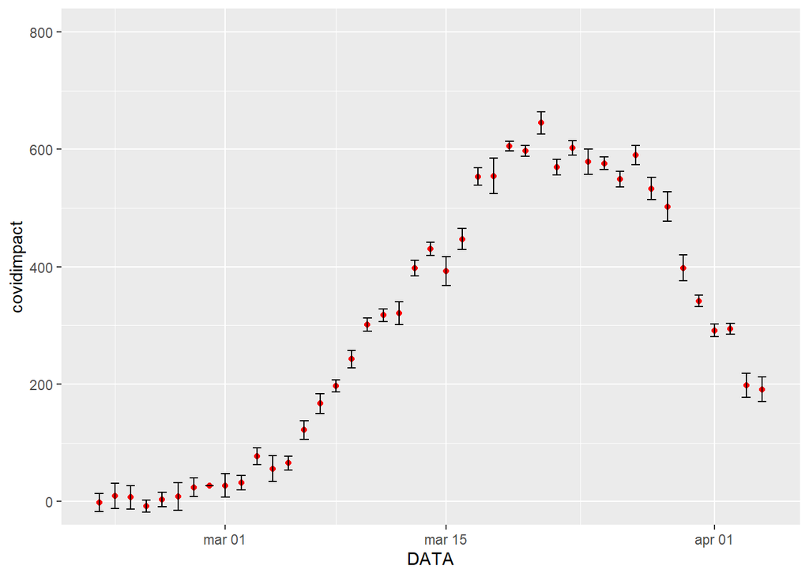

```r
lomb$covidimpact=lomb$TOTALE_20-lomb$mediaanniprec
lomb$sd_decessi<-apply(lomb[,c(2:6)],MARGIN=1, sd)
lomb[8,'sd_decessi']<-0

ggplot(lomb,aes(x=DATA,y=covidimpact))+
  geom_point(col='red')+
  coord_cartesian( ylim = c(0, 800))+
  geom_errorbar(aes(ymin=covidimpact-sd_decessi,
                    ymax=covidimpact+sd_decessi), width=.55)
```

## Trattazione comuni con valori mancanti

Si applica un filtro ai dati iniziali per cui si considerano soloi dati mancanti, sempre riguardo alla Lombardia,nello stesso periodo del dataset precedente.Si raggruppa per data computando le somme dei decessi totali di ogni anno. Successivamente,Si crea una variabile che riassume la media dei decessi degli anni precedenti al 2020. infine si crea una variabile che indica l’incremento percentuale dei decessi del 2020 rispetto alla media degli anni precedenti per ciascun giorno dell’intervallo considerato, all’interno del dataset privo di valori mancanti.

```r
dati%>% filter(DATA_INIZIO_DIFF == "Dati 2020 n.d.",
               NOME_REGIONE == "Lombardia",
               TOTALE_20 == 9999,
               GE>=222,
               GE<=404) %>%
  select(-TOTALE_20)->dati_nd2020


dati_nd2020 %>% group_by(DATA) %>%
  summarise(TOTALE_15 = sum(TOTALE_15),TOTALE_16=sum(TOTALE_16)
            ,TOTALE_17=sum(TOTALE_17),TOTALE_18=sum(TOTALE_18),
            TOTALE_19=sum(TOTALE_19)) -> lomb_2


lomb_2$mediaanniprec=(lomb_2$TOTALE_15+lomb_2$TOTALE_16+
                        lomb_2$TOTALE_17+lomb_2$TOTALE_18+
                        lomb_2$TOTALE_19)/5

lomb$covidimpact_perc=apply(lomb,MARGIN = 1,function(x) (as.numeric(x['covidimpact'])*100)/as.numeric(x['mediaanniprec']))
```

Si crea una funzione che calcola i decessi dei comuni con valori mancanti supponendo che essi abbiano al massimo un incremento del 20% rispetto alla media degli anni precedenti. Nei giorni in cui i decessi da Covid dei comuni con dati conosciuti e affidabili sono minori del 20%, la funzione pone come margine massimo per calcolare i dati mancanti l’incremento percentuale dei comuni con dati affidabili.Nel caso in cui i comuni conosciuti hanno una crescita negativa nei decessi, la funzione pone la crescita di decessi a 0. Si applica la funzione computando il margine superiore di decessi nei comuni mancanti, rispetto a ciascun giorno. Si trova così il margine totale dei decessi nei comuni mancanti.

```r
margine_sup<-function(x){
  y<-0
  i<-x[1]
  perc<-lomb[which(lomb$DATA==i),'covidimpact_perc']
  if(perc<20 & perc>0){y<-as.numeric(x[7])*(perc/100)}
  else if(perc<=0){y<-0}
  else {y<-as.numeric(x[7])*0.2}
  return(round(y,2))
}


lomb_2$margine_sup<-apply(lomb_2,MARGIN = 1,margine_sup)

sum(as.numeric(lomb_2$margine_sup))
```

```
## [1] 547.87
```

Dunque l’impatto di COVID-19 sui decessi nei comuni con dati mancanti risulta nell’intervallo tra 0 e 548 morti. Infine, considerando il range di valori trovato per i comuni con dati affidabili si trova l’intervallo definitivo.

```r
rangefin=c(rangeinf,rangesup+sum(as.numeric(lomb_2$margine_sup)))
rangefin
```

```
## [1] 12524.38 13706.69
```

Si può dunque concludere che, considerando i dati ISTAT, la conta dei decessi dell’anno 2020 in eccesso rispetto alla media del quinquennio precedente nel periodo che va dal 22 Febbraio al 4 Aprile in Lombardia ricade nella forchetta di valori tra 12524 e 13707 morti. Tale eccesso viene ricondotto alla diffusione dell’epidemia di COVID-19.